# Analysis of single cell data

Data preprocessing and QC

Author

Jennifer Fransson, NBIS

Published

May 26, 2025

```r
library(ggplot2)
library(cowplot)

source("R/themes.R")
```

# Study description

# Workflow

For this analysis, the R package `targets` is used to manage the workflow. This enables caching of intermediate files without manual management, thus reducing risk of mismatched intermediate files after analysis parameters have been modified.

However, this means that the code in this report does not represent the full code necessary to generate the figures. Instead, the code used to produce the R objects used here can be found primarily in the files _targets.R and R/functions.R. To see which functions and parameters have generated each object, the following code can be run within the repository directory to generate a workflow chart:

```
library(targets)
tar_visnetwork()
```

Documentation about the package can be found [here](https://books.ropensci.org/targets/).

The workflow is checked and rerun if necessary using the command `tar_make()` or `tar_make_future()` (the latter enables parallelization).

```r
library(Seurat)
library(targets)
library(clustree)
library(dplyr)
```

```r
# Enables changing targets directory (Use tar_config_set to set up new project), e.g.
# tar_config_set(script = "_targets.R", store = "_targets", project = "main")

Sys.setenv(TAR_PROJECT = "main")
```

```r
tar_make_future()
```

# Original data

```r
tar_load(obj_orig_meta)
tar_load(qc_groupby)
```

Original cell counts per sample:

```r
knitr::kable(as.data.frame(table(obj_orig_meta[[tar_read(qc_groupby)]])), col.names = c("sample","no of cells"))
```

| sample | no of cells |
| --- | --- |
| Sample1 | 1500 |
| Sample2 | 1500 |

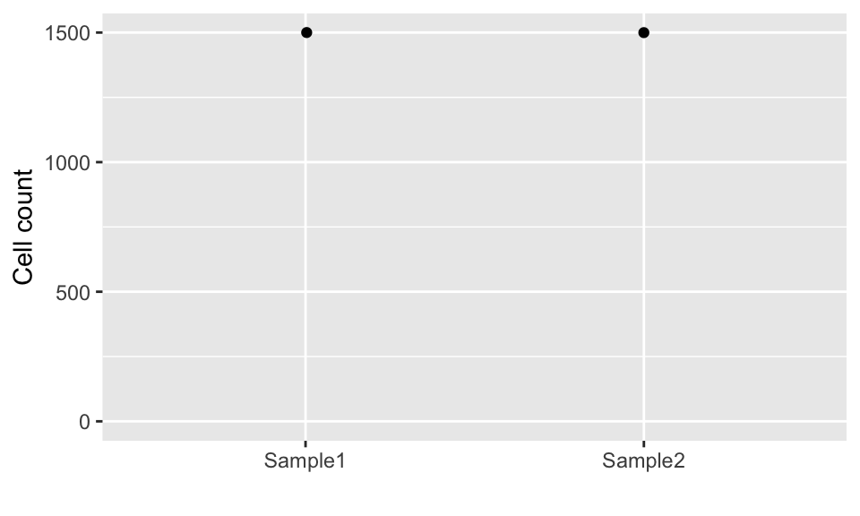

```r
cellcounts = as.data.frame(table(obj_orig_meta[[tar_read(qc_groupby)]]))
cellcounts$Group = obj_orig_meta[,qc_groupby][match(cellcounts$Var1, obj_orig_meta[[tar_read(qc_groupby)]])]
ggplot(cellcounts, aes(x = Group, y = Freq)) + geom_jitter(width = 0.1) + lims(y = c(0,NA)) +
  labs(x = "", y = "Cell count")
```

# Quality control and filtering

```r
tar_load(qc_filt_rules)

thresholds = data.frame(
  Parameter = sapply(qc_filt_rules, function(x){
    if(length(x)>3){
      x[[4]]
    }else{
      paste(x[[1]], x[[2]])
    }
  }),
  Value = sapply(qc_filt_rules, "[[", 3))
```

| Parameter | Value |
| --- | --- |
| Min number of unique features per cell | 2e+02 |
| Max number of reads (unique UMIs) per cell | 1e+06 |
| Max % mitochondrial reads per cell | 2e+01 |
| Min % ribosomal reads per cell | 5e+00 |

In addition, genes were removed from the data sets unless they were expressed in > 10 cells.

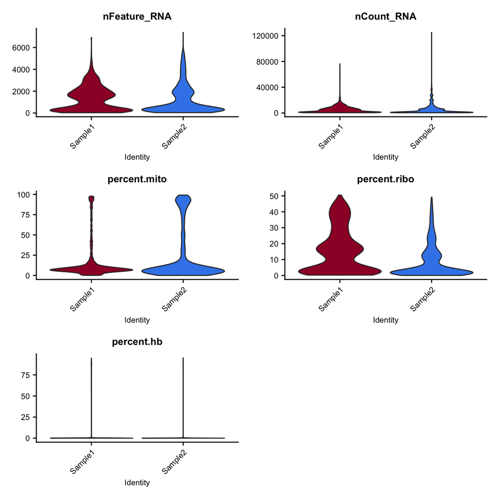

```r
tar_read(qc_unfiltered_vln)
```

After the first filtering, the distribution of QC variables are as shown:

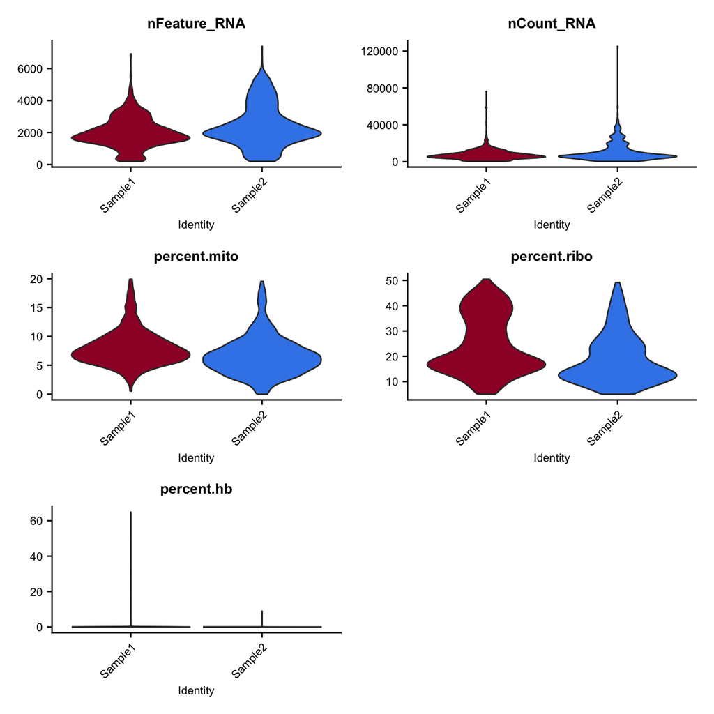

```r
tar_read(qc_filtered_vln)
```

In addition to filtering genes based on the number of cells expressing the gene, individual genes can be removed for reasons such as expected technical artefacts. To identify genes that may introduce biases, we visualize the genes with the highest median expression across cells.

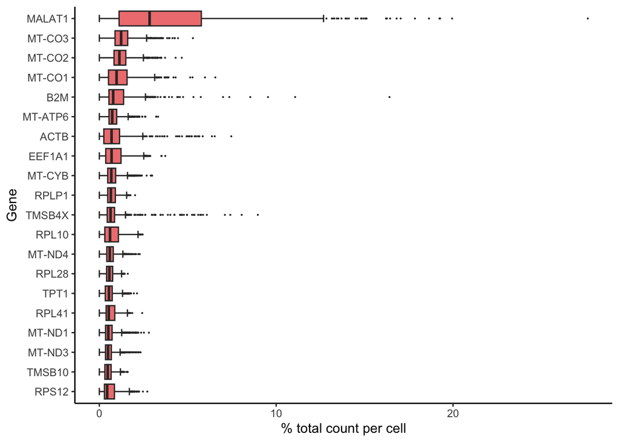

```r
tar_read(top_expr_boxplot)
```

The removed genes contain the following patterns:

```r
genes_to_remove = sapply(tar_read(qc_genesToRemove),
                         function(g){
                           paste0("^",g,"$")
})

patterns = c(tar_read(qc_genePatternsToRemove), genes_to_remove)

if(length(patterns)>0){
  remove_df =
    knitr::kable(data.frame(
  Pattern = gsub("\\^","", gsub("\\$","",patterns)),
  Rules =
  sapply(patterns, function(x){
  rules = c()
  if(substr(x, 1, 1) == "^"){
    rules = c(rules, "Begins with")
  }
  if(substr(x, nchar(x), nchar(x)) == "$"){
    rules = c(rules, "Ends with")
  }
  paste0(rules, collapse = " & ")
})))
}else{
  remove_df = "*No genes were selected for removal*"
}
```

| Pattern | Rules |
| --- | --- |
| RP[SL] | Begins with |
| MT- | Begins with |
| MALAT1 | Begins with & Ends with |

## Cell cycle prediction

In order to estimate whether there are differences between samples considering the cell cycle state at time of collection, and whether this needs to be accounted for downstream, “cell cycle scores” are added. This is an average of scaled expression of a list of genes indicative of the S phase and the G2-M phase in the cell cycle.

To specify which genes should be used for S phase and G2/M phase scores, edit the files *parameters/cc_S_genes.csv* and *parameters/cc_G2M_genes.csv* (note: these .csv-files should not contain column names). If no genes are indicated in these files, the default gene lists given by Seurat will be used (see `Seurat::cc.genes.updated.2019$s.genes` and `Seurat::cc.genes.updated.2019$g2m.genes`). Note that these default lists concern human genes.

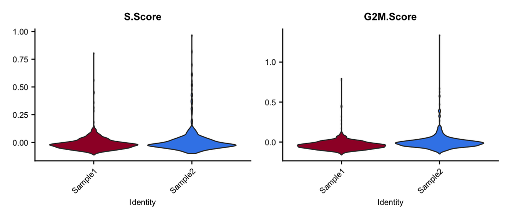

```r
tar_read(cc_violin)
```

## Doublet prediction

```r
if(tar_read(qc_runDF)){
  DFmessage = 'In droplet-based sequencing, a number of droplets containing more than one cell is expected. In order to predict which "cells" in the dataset are actually composed of more than one cell, the package [DoubletFinder](https://github.com/chris-mcginnis-ucsf/DoubletFinder) is used. Doublet cells are then removed from the dataset. To inform how many doublets could be expected, the column expectedCells in the metadata was used."

To evaluate whether the doublet prediction worked well, we look at two plots:

1. A preliminary UMAP in which doublets are indicated (doublets are likely to be found between clusters)

2. A violin plot showing the distribution of number of unique features per cell, split by predicted doublets and singlets in each sample (on average, doublets have a higher number of unique genes)'
}else{
  DFmessage = "Doublet removal was not performed."

}
```

In droplet-based sequencing, a number of droplets containing more than one cell is expected. In order to predict which “cells” in the dataset are actually composed of more than one cell, the package DoubletFinder is used. Doublet cells are then removed from the dataset. To inform how many doublets could be expected, the column expectedCells in the metadata was used.”

To evaluate whether the doublet prediction worked well, we look at two plots:

1. A preliminary UMAP in which doublets are indicated (doublets are likely to be found between clusters)
2. A violin plot showing the distribution of number of unique features per cell, split by predicted doublets and singlets in each sample (on average, doublets have a higher number of unique genes)

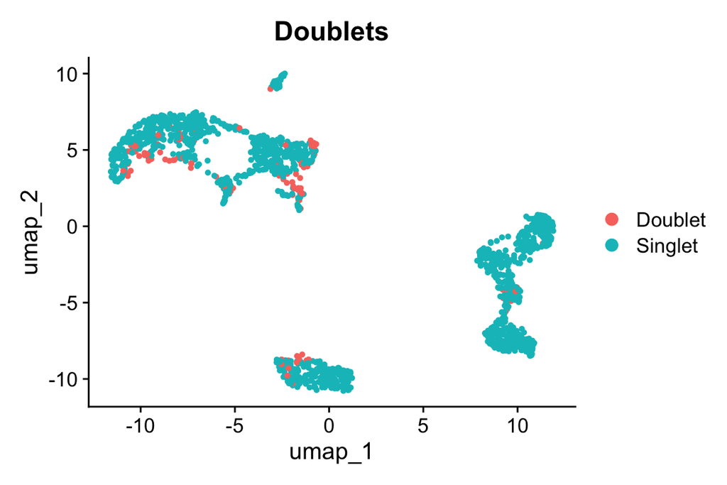

```r
if(tar_read(qc_runDF)){
  tar_read(doublet_plots)$dimplot & labs(title = "Doublets")
}
```

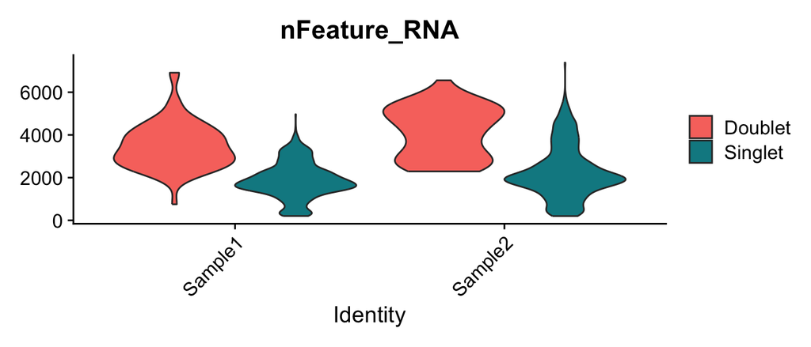

```r
if(tar_read(qc_runDF)){
  tar_read(doublet_plots)$vlnplot
}
```

## Final cell counts

The final number of cells are as follows:

```r
tar_load(obj_filt_final_meta)
```

```r
knitr::kable(as.data.frame(table(obj_filt_final_meta[[tar_read(qc_groupby)]])), col.names = c("sample","no of cells"))
```

[output not shown]

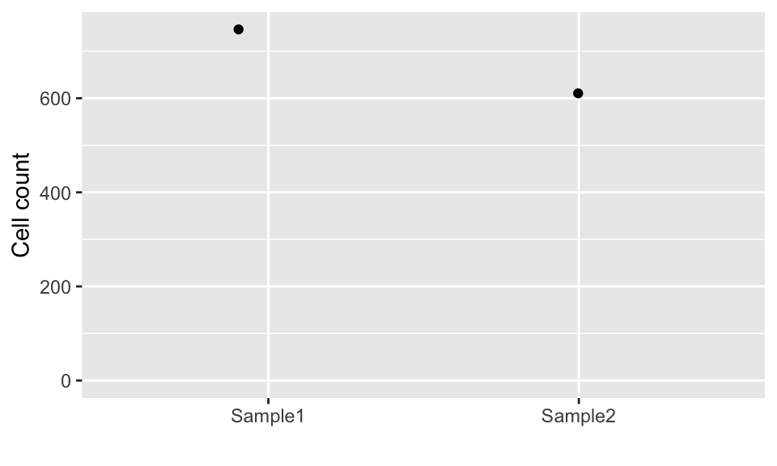

```r
cellcounts = as.data.frame(table(obj_filt_final_meta[[tar_read(qc_groupby)]]))
cellcounts$Group = obj_filt_final_meta[,qc_groupby][match(cellcounts$Var1, obj_filt_final_meta[[tar_read(qc_groupby)]])]
ggplot(cellcounts, aes(x = Group, y = Freq)) + geom_jitter(width = 0.1) + lims(y = c(0,NA)) +
  labs(x = "", y = "Cell count")
```

The distributions of the QC variables are also shown.

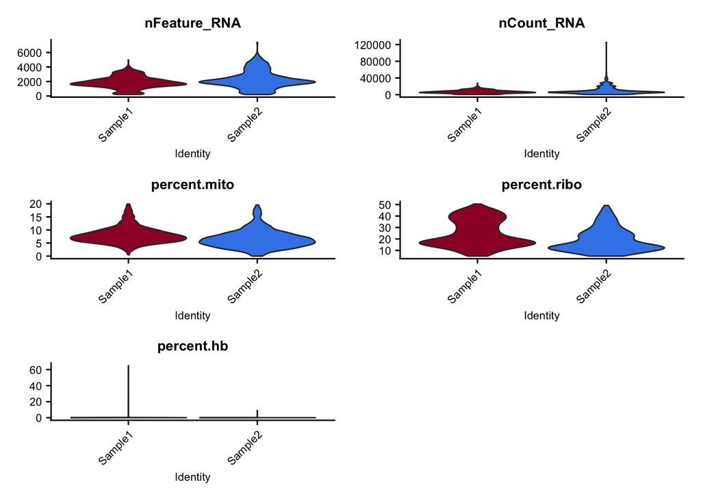

```r
tar_read(qc_final_vln)
```

# Normalization

```r
if(tar_read(dimred_sct)){
  normalization_method = paste0("Normalization was performed using the SCTransform method on the top ",
                                tar_read(dimred_nHVG)," most variable features.")
  if(length(tar_read(dimred_varstoregress))>0){
    normalization_method = paste0(normalization_method, " The following variables were regressed out: ",
                                  paste0(tar_read(dimred_varstoregress), collapse = ", "),".")
  }
}else{
  normalization_method = "Normalization was performed using the NormalizeData method."
  if(length(tar_read(dimred_varstoregress))>0){
    normalization_method = paste0(normalization_method, " The following variables were regressed out when scaling the top ",
                                  tar_read(dimred_nHVG)," most variable features: ",
                                  paste0(tar_read(dimred_varstoregress), collapse = ", "),".")
  }
}

if(!tar_read(load_joinlayers)){
  HVGmessage = "*Note: This analysis uses the feature of layers introduced in Seurat v5. A feature of this functionality is that variance for each gene is calculated on each original sample individually, and the variability for each gene is calculated based on the ranks in each sample. This means that unlike previous Seurat versions, the genes with the most variability in the plot are not necessarily the most variable when combining the ranked lists.*"
}else{
  HVGmessage = ""
}
```

Normalization was performed using the NormalizeData method. The following variables were regressed out when scaling the top 2000 most variable features: nFeature_RNA.

# Dimensional reduction

```r
tar_load(obj_pca_umap)
```

## PCA

```r
tar_load(dimred_pca_parameters)

if(length(dimred_pca_parameters)>0){
  pca_par_used = TRUE
  if(!is.null(dimred_pca_parameters$features)){
    pca_feature_text = "a custom list of genes."
  }
}
if(!exists("pca_feature_text")){
  pca_feature_text = paste0("the top ",tar_read(dimred_nHVG)," most variable features.")
}
```

Dimensional reduction was performed using PCA based on the top 2000 most variable features. They are visualized below (in red), showing the mean expression and standardized variance for each gene. The top 20 genes are labeled.

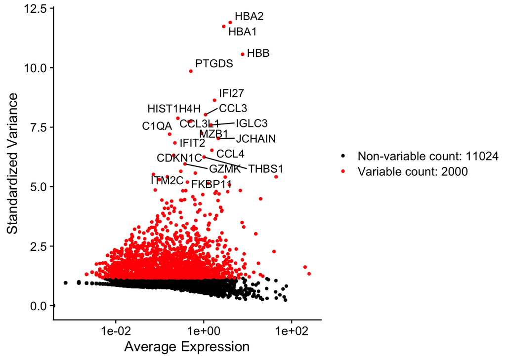

```r
top20 <- head(VariableFeatures(obj_pca_umap), 20)

LabelPoints(plot = tar_read(dimred_varfeat_plot), points = top20, repel = TRUE)
```

The top variable genes are used to produce an initial PCA.

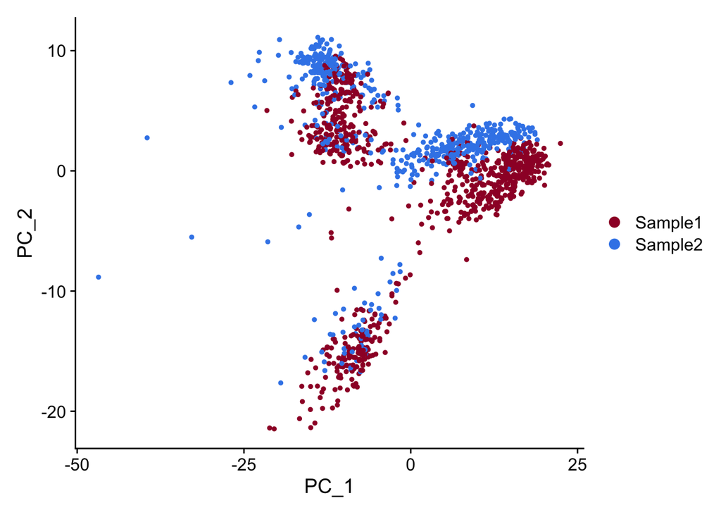

```r
addColors(DimPlot(obj_pca_umap, reduction = "pca", shuffle = TRUE), layer = 1)
```

The top genes contributing positively or negatively to the first 4 principal components are as shown:

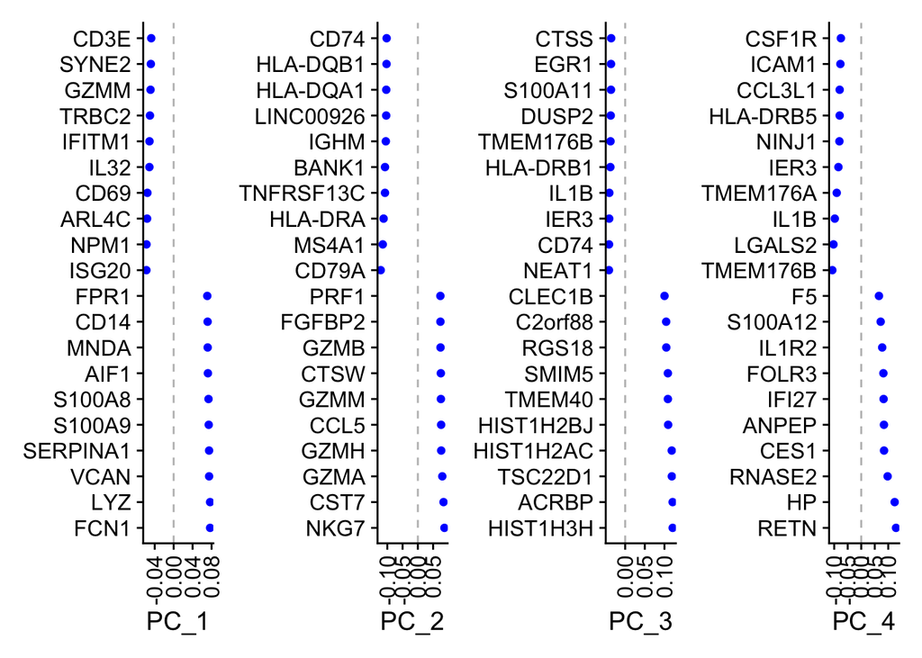

```r
VizDimLoadings(obj_pca_umap, dims = 1:4, nfeatures = 20, balanced = TRUE, ncol = 4) &
  geom_vline(xintercept = 0, linetype = 2, color = "grey") &
  theme(axis.text.x = element_text(angle = 90, hjust = 1, vjust = 0.5))
```

The variance explained by each PC helps us estimate how many PCs will be useful to include in order to retain maximum variance while reducong noise. An “elbow plot” is useful for this.

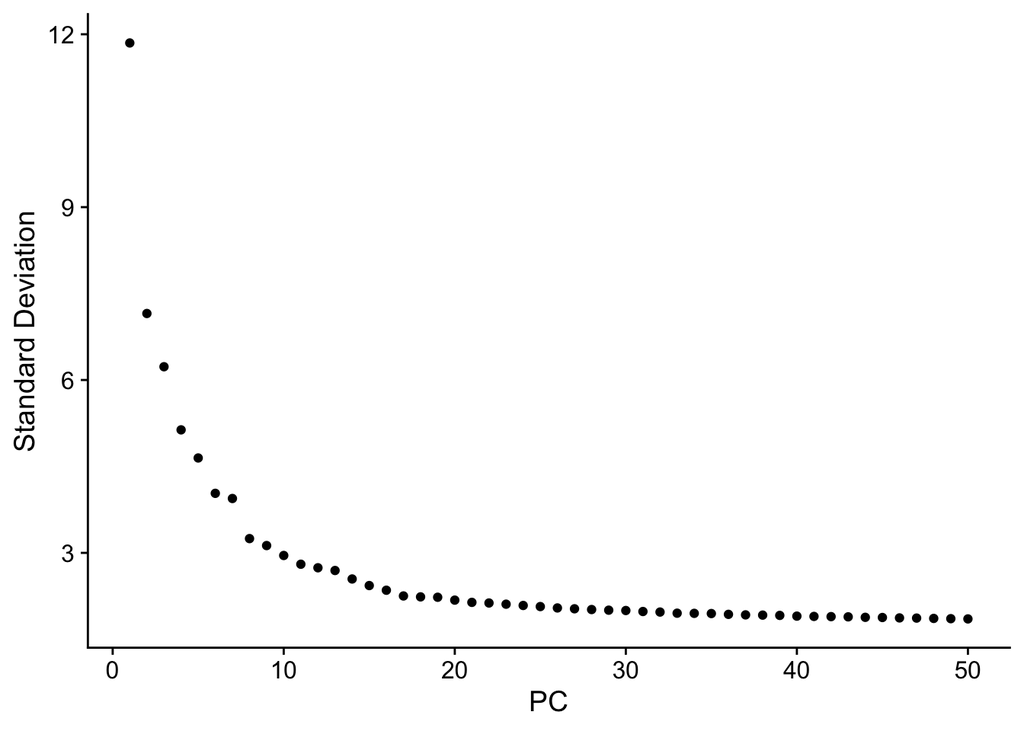

```r
ElbowPlot(obj_pca_umap, ndims = 50)
```

## UMAP

A UMAP was produced to visualize the relative similarities between cells. For this, the following parameters were set:

```r
shortenvector = function(x){
  if(length(x)>1){
    if(is.numeric(x) | is.integer(x)){
      if(identical(as.numeric(x), as.numeric(min(x):max(x)))){
        x = paste0(min(x), ":", max(x))
      }
    }
    x = paste0(x, collapse = ", ")
  }
  x
}

umap_params = data.frame(
  Parameter = c("Number of neighbors",
                "Number of components to produce",
                "Minimum distance",
                "Number of PCs to consider"),
  Value = c(
    shortenvector(tar_read(dimred_umap_nn)),
    shortenvector(tar_read(dimred_umap_ncomp)),
    shortenvector(tar_read(dimred_umap_mindist)),
    shortenvector(tar_read(dimred_umap_dims))
    )
)
```

| Parameter | Value |
| --- | --- |
| Number of neighbors | 30 |
| Number of components to produce | 2 |
| Minimum distance | 0.3 |
| Number of PCs to consider | 1:20 |

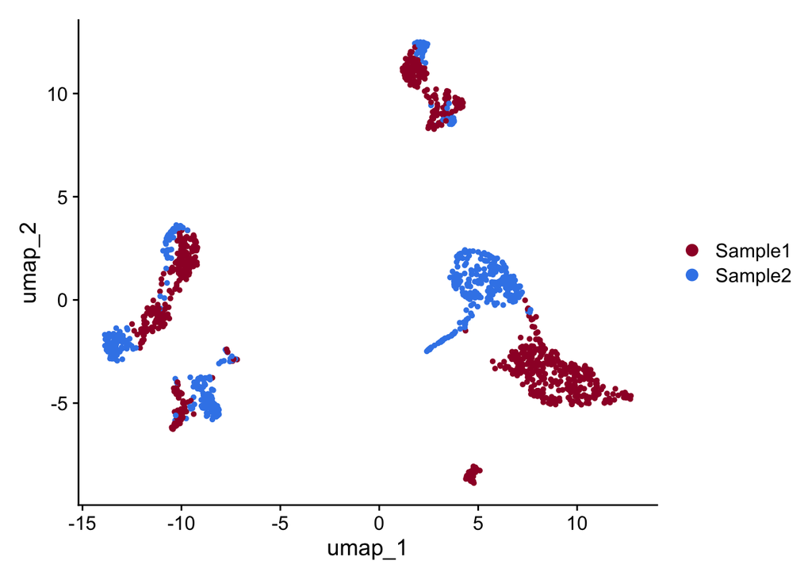

```r
addColors(DimPlot(obj_pca_umap, shuffle = TRUE), layer = 1)
```

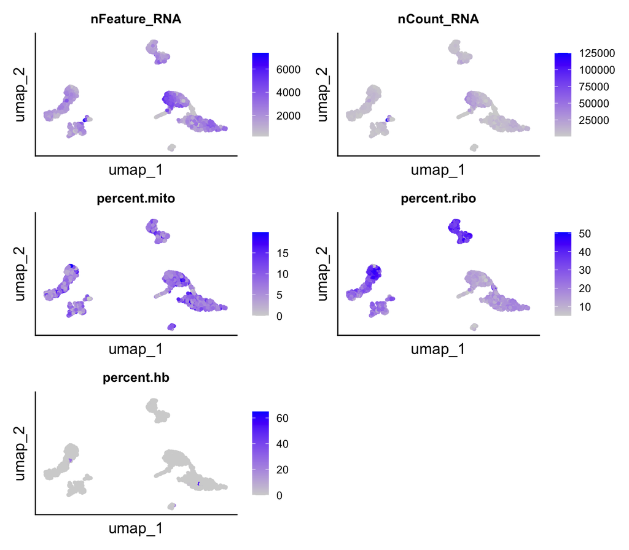

```r
FeaturePlot(obj_pca_umap, c("nFeature_RNA","nCount_RNA","percent.mito", "percent.ribo","percent.hb"), ncol = 2) &
  theme(plot.title = element_text(size = 12),
        legend.text = element_text(size =10),
        axis.text = element_blank(),
        axis.ticks = element_blank())
```

```r
rm(obj_pca_umap)
gc()
```

# Integration

```r
if(tar_read(run_int)){
  intmessage = paste0("Integration was run to reduce batch effects considering each ",tar_read(int_split)," as a separate batch.")
  show_int = TRUE
}else{
  intmessage = "Integration between samples/batches was not run in this analysis."
  show_int = FALSE
}
```

Integration was run to reduce batch effects considering each Sample as a separate batch.

```r
tar_load(obj_int_umap)
```

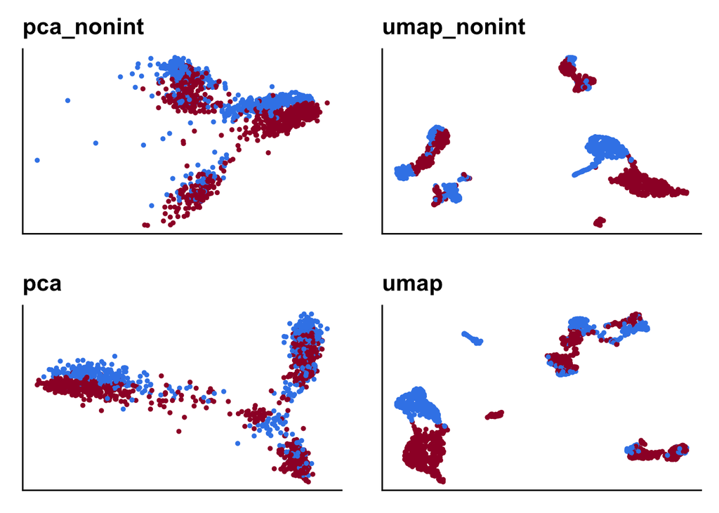

```r
reductions = c(
  "pca_nonint","umap_nonint",
  ifelse(tar_read(load_joinlayers), "pca","integrated.cca"),
  "umap"
)

plot_grid(
  plotlist =
    lapply(reductions, function(red){
      addColors(DimPlot(obj_int_umap, reduction = red, shuffle = TRUE) &
        NoLegend() &
        theme(axis.text = element_blank(), axis.title = element_blank(),
              axis.ticks = element_blank()) &
        labs(title = red), layer = 1)
}))
```

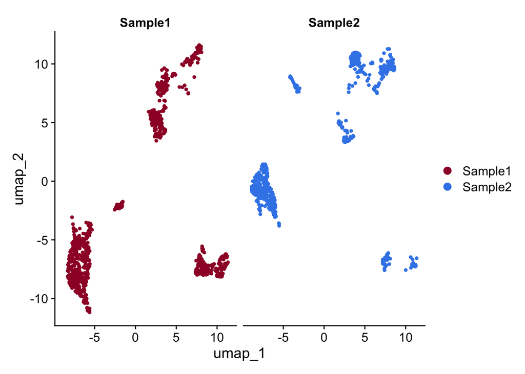

```r
addColors(DimPlot(obj_int_umap, reduction = "umap", shuffle = TRUE,
                  split.by = tar_read(int_split)), layer = 1)
```

```r
rm(obj_int_umap)
gc()
```

# Clustering

Clustering was performed on the reduction pca, at resolutions 0.25, 0.5, 1, 1.5.

```r
tar_load(obj_clus)
```

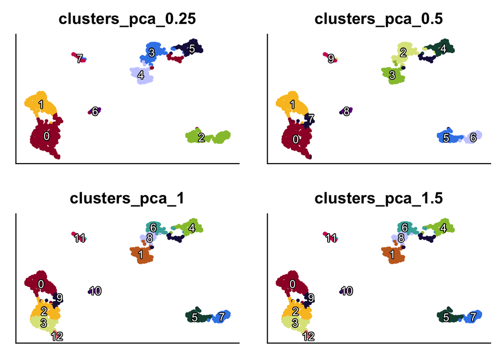

```r
clustername = paste0("clusters_",tar_read(clus_reduction),"_")

clustering = colnames(obj_clus@meta.data)[grepl(clustername, colnames(obj_clus@meta.data))]
plot_grid(
  plotlist =
    lapply(clustering, function(clus){
      shadow_text(addColors(DimPlot(obj_clus, reduction = "umap", shuffle = TRUE,
              group.by = clus, label = TRUE) &
        NoLegend() &
        theme(axis.text = element_blank(), axis.title = element_blank(),
              axis.ticks = element_blank()) &
        labs(title = clus),
        scale_type = "colour", layer = 1))
}))
```

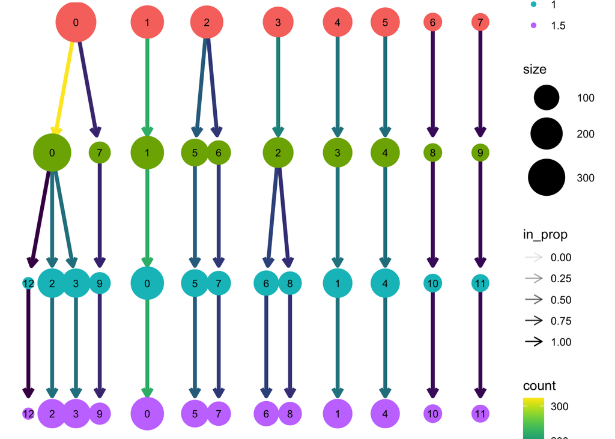

```r
clustree(obj_clus, prefix = clustername)
```

## Resolution for annotation

```r
cluster_res = paste0("clusters_",
                     tar_read(clus_reduction),
                     "_",
                     tar_read(clus_de_res))
```

For annotation purposes and comparison between samples, a clustering resolution was chosen. For this report, the cluster of interest was clusters_pca_0.25.

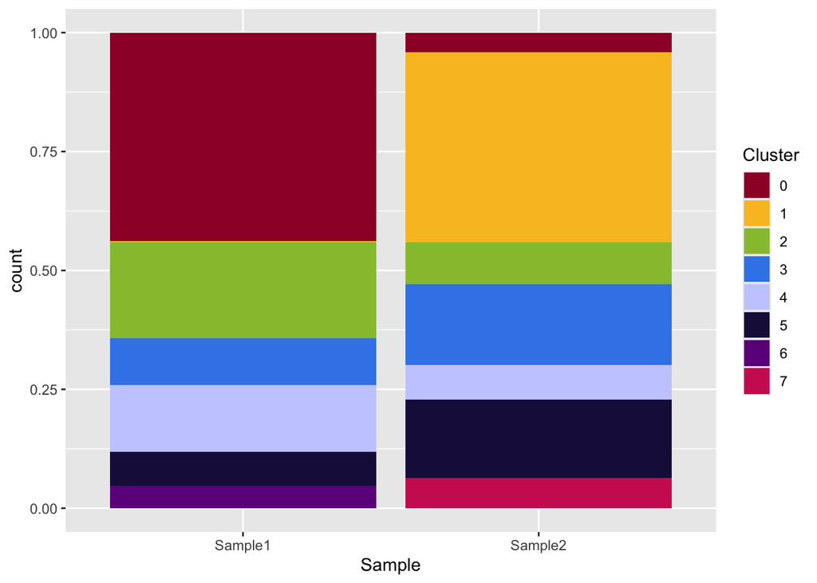

```r
obj_clus$Cluster = factor(obj_clus@meta.data[[cluster_res]])

addColors(ggplot(obj_clus@meta.data,
       aes(x = Sample)) +
  geom_bar(aes(fill = Cluster),
           position = "fill"),
  "fill", layer = 1)
```

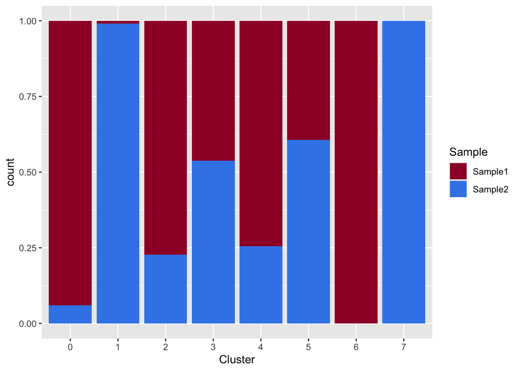

```r
addColors(ggplot(obj_clus@meta.data,
       aes(x = Cluster)) +
  geom_bar(aes(fill = Sample), position = "fill"),
  scale_type = "fill", layer = 1)
```

The distribution of QC variables and cell cycle scores are shown across clusters using violin plots.

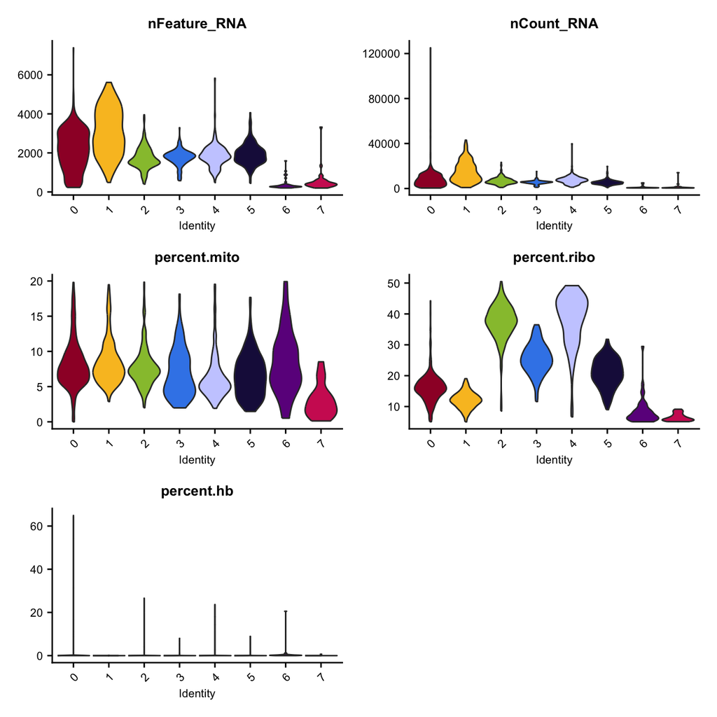

```r
addColors(VlnPlot(obj_clus,
        features = tar_read(qc_plotvars),
        group.by = "Cluster",
        pt.size = 0, ncol = 2) & violintheme(),
        scale_type = "fill")
```

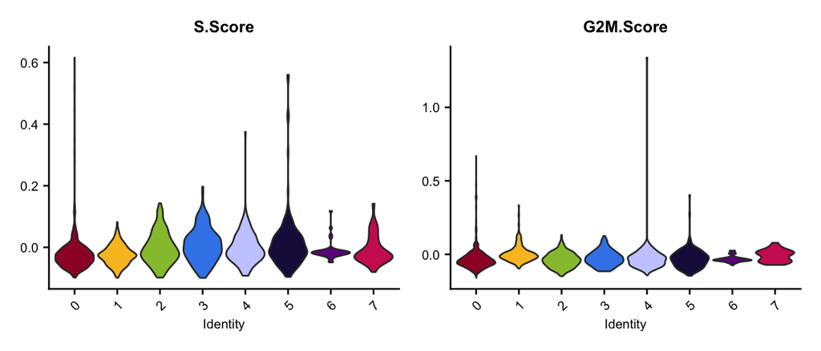

```r
addColors(VlnPlot(obj_clus,
        features = c("S.Score","G2M.Score"),
        group.by = "Cluster",
        pt.size = 0, ncol = 2) & violintheme(),
        scale_type = "fill")
```

Differential expression analysis was performed between clusters by comparing each cluster to all other clusters (“1-vs-all”).

The top 10 differentially expressed genes (DEGs) per cluster (based on p-value) are listed below. The bars show the log2(fold-change) of the DEG.

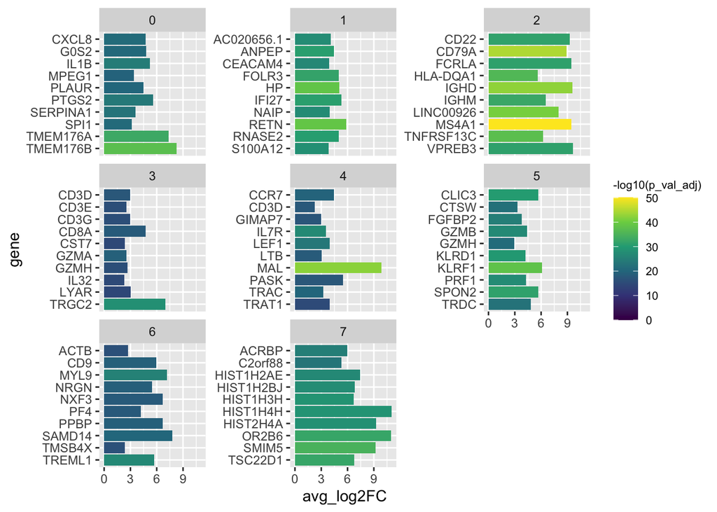

```r
tar_read(cluster_de_barplot)
```

Expression of the top 3 DEGs per cluster (based on p-value) are shown in across clusters in a dot plot and violin plots.

```r
top3 = unique(tar_read(cluster_de)$de_res %>%
  group_by(cluster) %>%
        filter(p_val_adj < 0.05) %>%
  slice_min(order_by = p_val_adj, n = 3) %>%
  slice_max(order_by = avg_log2FC, n = 3) %>%
    pull(gene))


obj_clus@active.assay = "RNA"
```

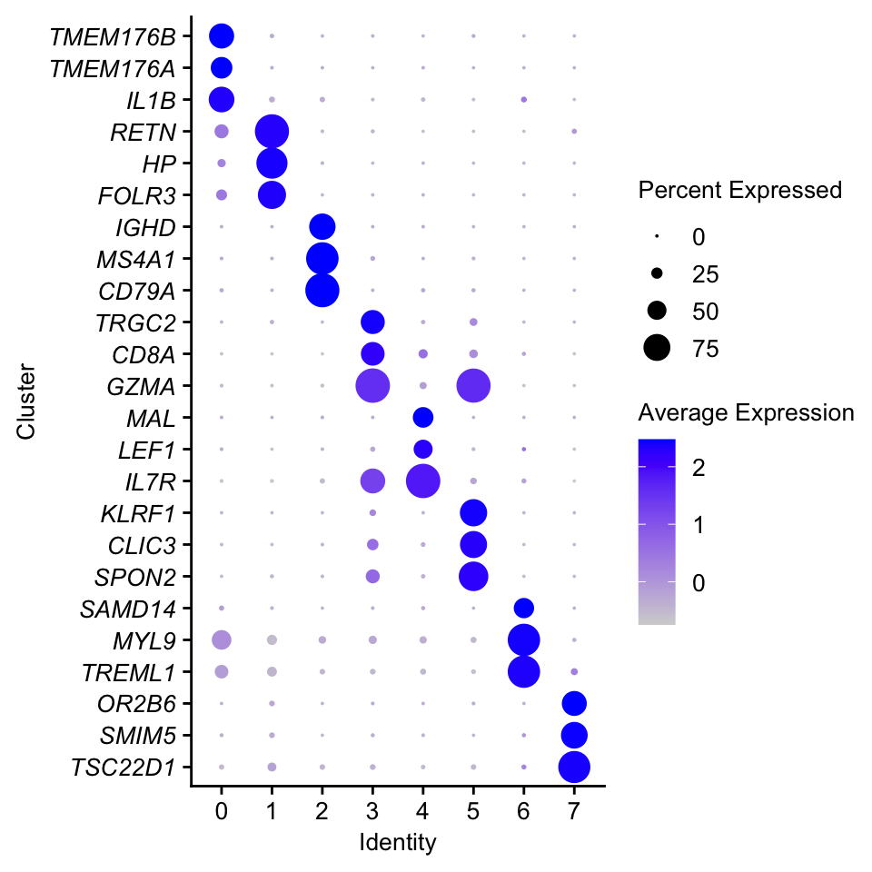

```r
DotPlot(obj_clus, features = rev(unique(top3)), group.by = "Cluster") + coord_flip() +
  theme(axis.text.y = element_text(face = "italic")) +
  labs(x = "Cluster") +
  dottheme()
```

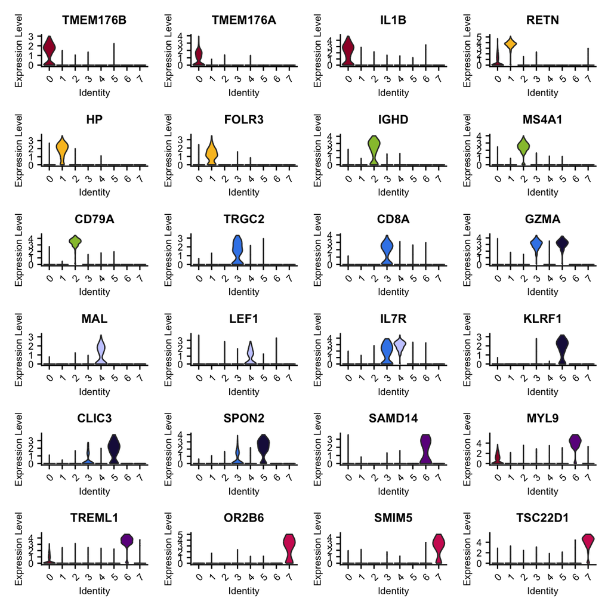

```r
addColors(VlnPlot(obj_clus, group.by = "Cluster",
        features = top3, pt.size = 0) &
  violintheme(), scale_type = "fill")
```

# Reproducibility

## Workflow warnings

Below are any warnings produced during the targets workflow.

```r
knitr::kable(targets::tar_meta(fields = warnings, complete_only = TRUE))
```

| name | warnings |
| --- | --- |
| doublet_plots | The default method for RunUMAP has changed from calling Python UMAP via reticulate to the Rnative UWOT using the cosine metricTo use Python UMAP via reticulate, set umap.method to umaplearn and metric… |
| metadata | incomplete final line found by readTableHeader on datametadata.csv |
| obj_cc | The following features are not present in the object RAD51, not searching for symbol synonyms. The following features are not present in the object PIMREG, CDC25C, not searching for symbol synonyms |
| obj_df | The default method for RunUMAP has changed from calling Python UMAP via reticulate to the Rnative UWOT using the cosine metricTo use Python UMAP via reticulate, set umap.method to umaplearn and metric… |
| obj_filt | No layers found matching search pattern provided. data layer is not found and counts layer is used |
| obj_int | Different features in new layer data than already exists for scale.data. Number of dimensions changing from 50 to 30 |
| obj_int_umap | The default method for RunUMAP has changed from calling Python UMAP via reticulate to the Rnative UWOT using the cosine metricTo use Python UMAP via reticulate, set umap.method to umaplearn and metric… |
| obj_pca | invoke is deprecated as of rlang 0.4.0.Please use exec or inject instead.This warning is displayed once every 8 hours. |
| obj_pca_umap | The default method for RunUMAP has changed from calling Python UMAP via reticulate to the Rnative UWOT using the cosine metricTo use Python UMAP via reticulate, set umap.method to umaplearn and metric… |
| qc_unfiltered_vln | Subsetting quosures with is deprecated as of rlang 0.4.0Please use quo_get_expr instead.This warning is displayed once every 8 hours. |